# TCC: Remuneração do sistema judiciário brasileiro

# Dados do Sistema de Justiça Brasileiro

A Lei Federal 12.527/2011, ou mais comumente conhecida como Lei de Acesso à Informação (LAI), diz que é “obrigatória a divulgação em sítios oficiais da rede mundial de computadores (internet)” dos dados de gastos públicos. Por isso, órgãos que fazem parte do sistema de justiça periodicamente disponibilizam em seus sites informações detalhada sobre seus gastos, que são disponíveis para todos. Uma parte importante desses gastos são as remunerações dos trabalhadores e trabalhadoras desses órgãos. Os agentes públicos do sistema de justiça brasileiro recebem outras verbas, além de seus salários, para exercerem seus cargos. Dentre elas encontramos auxílio moradia, despesas com saúde, auxílio transporte, gratificações, diárias, entre outros benefícios. Dados detalhados sobre essas remunerações devem ser disponibilizados nos sites de cada órgão. Devido a grande quantidade de auxílios é importante ter um controle sobre esses gastos e verificar a moralidade e legitimidades do recebimento desses benefícios.

## Remunerção x salário

As remunerações¹ incluem valores que vão além do salário². Os conhecidos auxílios, benefícios ou indenizações, são gastos eventuais que podem constituir as remunerações. Auxílios como alimentação, pré escolar, saúde, natalidade, moradia e ajuda de custo, são exemplos de benefícios que podem ser recebidas por funcionários dos tribunais e ministérios públicos do Brasil

- ¹Remuneração: é a soma do salário mais outras vantagens (indenizações e auxílios).
- ²Salário: valor recebido de acordo com a prestação de serviços, em decorrência do contrato de trabalho. Valor fixo mensal.

## Descrição dos dados

Os dados utilizados nessa análise foram conseguidos através da iniciativa do DadosJusBR, que teve início no Hackfest (2018) e até hoje desenvolve trabalhos de libertação dos dados de remuneração do sistema de justiça brasileiro.

Abaixo temos uma descrição das principais variáveis que estão disponíveis nos dados:

- subsidio = Salário recebido pelo magistrado
- direitos_pessoais = Total recebido através de direitos pessoais
- indenizações = Total recebido através de indenizações
- direitos_eventuais = Total recebido através de direitos eventuais
- total_descontos = Somatório de todos os descontos aplicados à remuneração do Magistrado
- rendimento_liquido = Subsídios + Adicionais - Descontos
- tottal_de_rendimentos = Total de rendimentos do Magistrado"

Ainda é possível encontrar todas os valores pormenorizados de cada benefício/indenização. Para ver o restante das colunas [aqui](https://github.com/davidedup/remuneracao-judiciario/blob/master/dados/2018-1-datapackage/data.csv).

# Como são as remunerações dos magistrados

### 2016

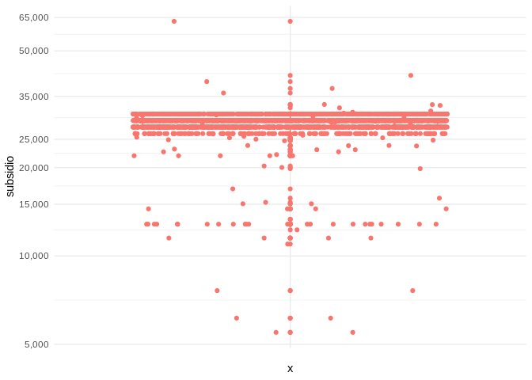

```r
dados_2016 %>%
  ggplot(aes(x=" ", y=subsidio, color=" ")) +
  geom_boxplot() +
  geom_jitter() +
  theme_minimal() +
  scale_y_log10(labels = scales::comma, breaks=c(5000, 10000, 15000, 20000,25000, 35000, 50000, 65000)) +
  theme(legend.position = "none")
```

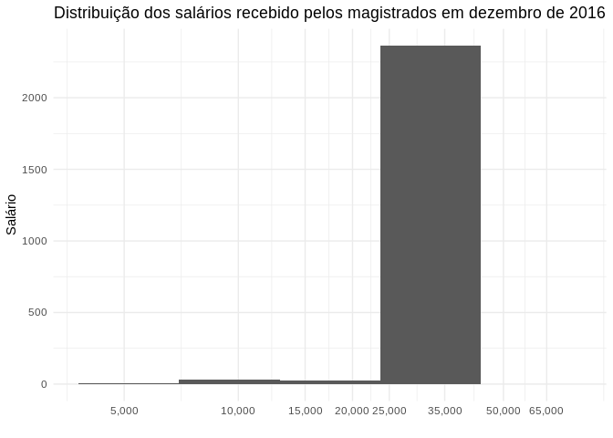

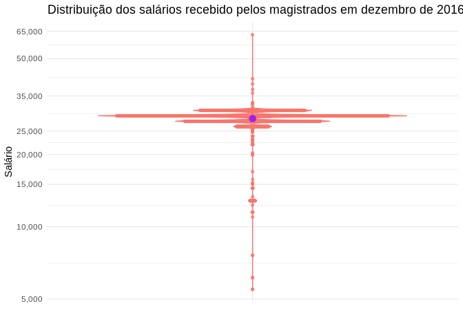

```r
dados_2016  %>%
  ggplot(aes(x=subsidio)) +
  geom_histogram(bins = 5) +
  theme_minimal() +
  scale_x_log10(labels = scales::comma, breaks=c(5000, 10000, 15000, 20000,25000, 35000, 50000, 65000)) +
  labs(x="", y = "Salário", title = "Distribuição dos salários recebido pelos magistrados em dezembro de 2016")
```

Analisando o ano de 2016 podemos observar que o salário mais baixo recebido foi de **5.489,26** por uma pensionista do Tribunal de Justiça do Estado do Acre isso é equivalente a 5,75 salários mínimos. Já o salário mais alto foi de **63.070,29** recebido por uma desembargadora federal do trabalho, esse valor é equivalente a 66,4 salários mínimos.

A média salarial foi de **28.374,57** com uma mediana de **28.947,55**

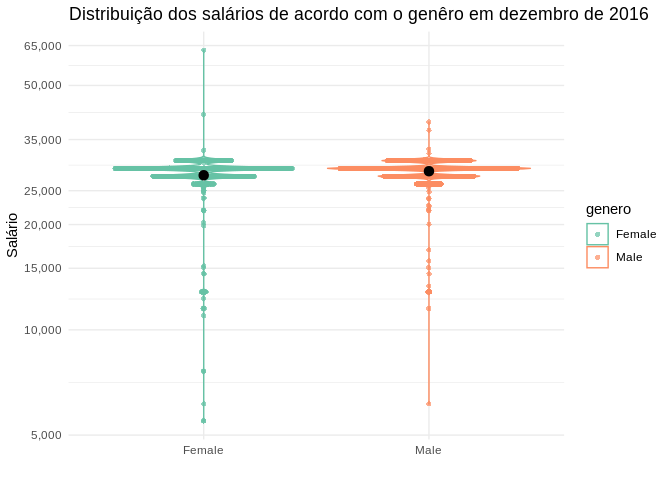

O total de funcionárias é de **775**, enquanto o de funcionários é de **1558**. Existem o dobro de funcionários do que de funcionárias no sistema de justiça brasileiro em dezembro de 2016. A média salárial para as mulheres é de **28.028,95** e para os homems é de **28.539,68**.

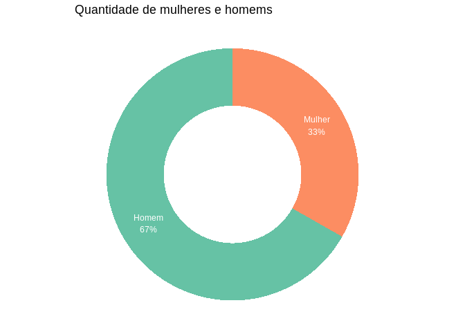

### Remuneração de acordo com cargo

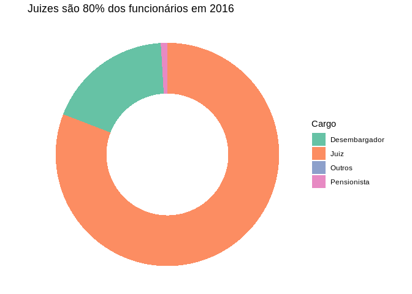

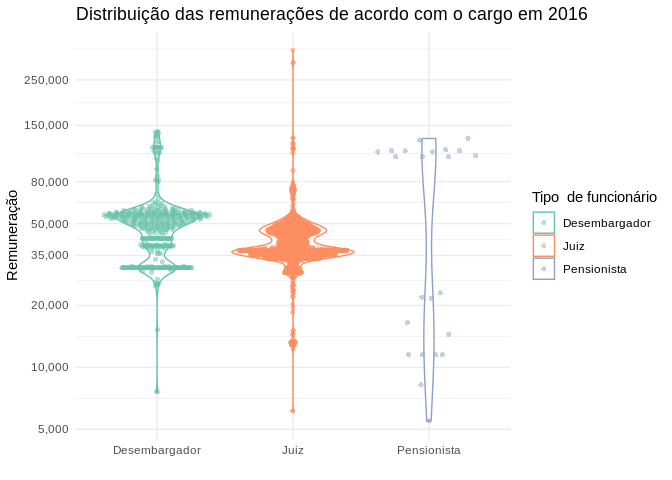

A média de remunerção de acordo com cada cargo tem a seguinte distribuição:

- A média de remuneração de um juiz em 2016 foi de: **40.834,32**
- A média de remuneração de um desembargador em 2016 foi de: **50.408,41**
- A média de remuneração de um pensionitsa em 2016 foi de: **65.893,33**

### Judiciário x outros trabalhadores

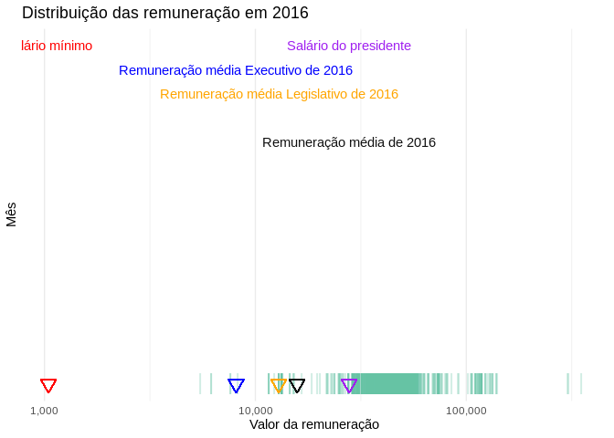

## Desvendando os benefícios

Iremos chamar de benefício qualquer valor recebido pelo funcionário ou funcionária que não seja parte do valor recebido como salário, mas constitue sua remuneração.

Alguns dos benefícios são:

- Diarias:Reembolso por despesas em serviços externos: alimentação, transporte, hospedagem e outros
- Abono Permanência: Bônus concedido a quem alcançou os requisitos para se aposentar, mas optou por permanecer em atividade
- Auxílio Alimentação: Indeniza gastos com alimentação
- Auxílio pré escolar: Também conhecido como auxílio creche, objetiva oferecer assistência ao atendimento de seus dependentes em idade pré-escolar
- Auxílio saúde: Concedido para custeio dos gastos com planos de saúde
- Auxílio natalidade: Concedido por motivo de nascimento de filho
- Auxilío moradia: Ressarcimento de despesas comprovadamente realizadas pelo servidor com aluguel de moradia ou com hospedagem em empresa hoteleira
- Ajuda de custo: Inclui despesas como mudança de cidade do magistrado e auxílios diversos - como bolsa livro
- Abono Constitucional de 1/3 de férias
- Indenização de férias: Recebido quando o magistrado não utiliza todo o período de férias ao qual tem direito
- Gratificação natalina: 1/12 da remuneração por mês trabalhado, o que totaliza um salário extra por ano

### 30% dos valores gastos com remuneração são proveniente de benefícios

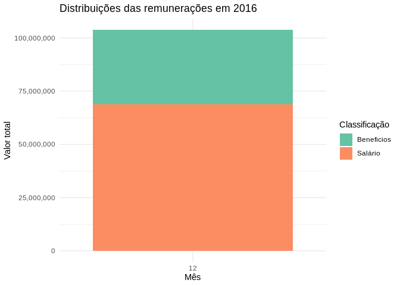

Em dezembro de 2016 o total gasto com salário foi de **68.779.952,08**. Enquanto o total gasto com benefícios foi de **35.000.962,87**

### Sumários de alguns benefícios

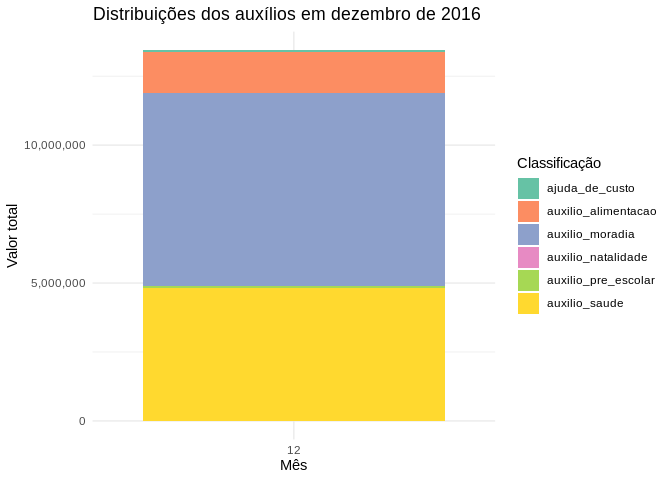

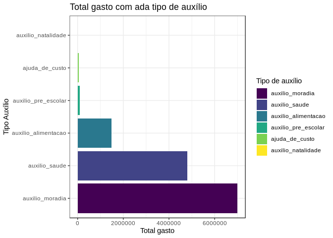

```r
# obter a ordenação do volume
idx <- order(stacked_bar_chart_auxilios$sum, decreasing = TRUE)
# criar os níveis ordenados
levels <- stacked_bar_chart_auxilios$type[idx]
# criar um factor com níveis ordenados
stacked_bar_chart_auxilios$type <- factor(stacked_bar_chart_auxilios$type, levels=levels, ordered=TRUE)

stacked_bar_chart_auxilios %>%
  ggplot(aes(x=sum, y=type, fill= type)) +
  geom_bar(stat="identity") +
  labs(x="Total gasto", y = "Tipo Auxílio", title = "Total gasto com ada tipo de auxílio", fill="Tipo de auxílio")
```

Os totais gastos com cada tipo de auxílio em dezembro de 2016 estão na tabela abaixo:

| type | mes | sum |
| --- | --- | --- |
| ajuda_de_custo | 12 | 57895.10 |
| auxilio_alimentacao | 12 | 1483666.53 |
| auxilio_moradia | 12 | 6994591.07 |
| auxilio_natalidade | 12 | 659.25 |
| auxilio_pre_escolar | 12 | 96251.92 |
| auxilio_saude | 12 | 4810980.96 |

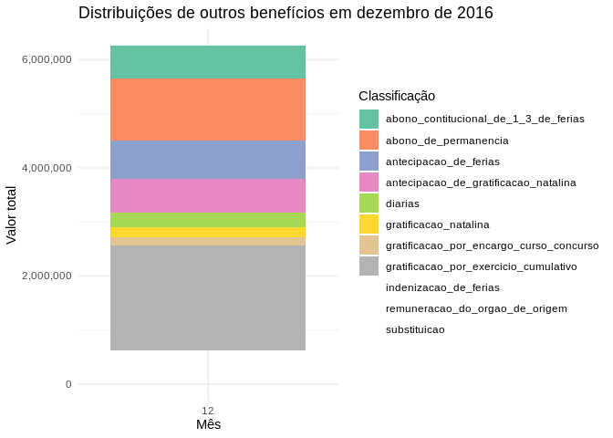

Os totais gastos com cada tipo de benefício de direito eventual e pessoal em dezembro de 2016 estão na tabela abaixo:

| type | mes | sum |
| --- | --- | --- |
| abono_contitucional_de_1_3_de_ferias | 12 | 606939.8 |
| abono_de_permanencia | 12 | 1145041.6 |
| antecipacao_de_ferias | 12 | 710738.5 |
| antecipacao_de_gratificacao_natalina | 12 | 627060.8 |
| diarias | 12 | 267777.3 |
| gratificacao_natalina | 12 | 180451.0 |
| gratificacao_por_encargo_curso_concurso | 12 | 151485.8 |
| gratificacao_por_exercicio_cumulativo | 12 | 1942036.6 |
| indenizacao_de_ferias | 12 | 449626.6 |
| remuneracao_do_orgao_de_origem | 12 | 0.0 |
| substituicao | 12 | 177262.7 |

### 2017

[output not shown]

[output cut: 65 more lines]

```
##  Min.   :     0            Length:22288                Min.   :11.00
##  1st Qu.:     0            Class :character            1st Qu.:11.00
##  Median :     0            Mode  :character            Median :11.00
##  Mean   :  1083                                        Mean   :11.04
##  3rd Qu.:     0                                        3rd Qu.:11.00
##  Max.   :241149                                        Max.   :12.00
##  NA's   :210
##       ano          genero
##  Min.   :2017   Length:22288
##  1st Qu.:2017   Class :character
##  Median :2017   Mode  :character
##  Mean   :2017
##  3rd Qu.:2017
##  Max.   :2017
##
```

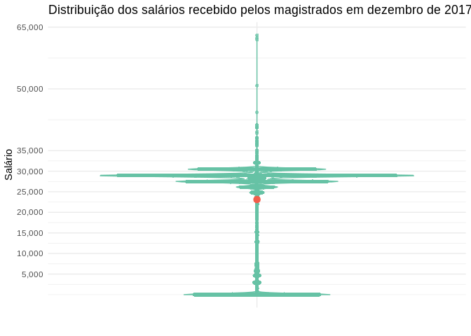

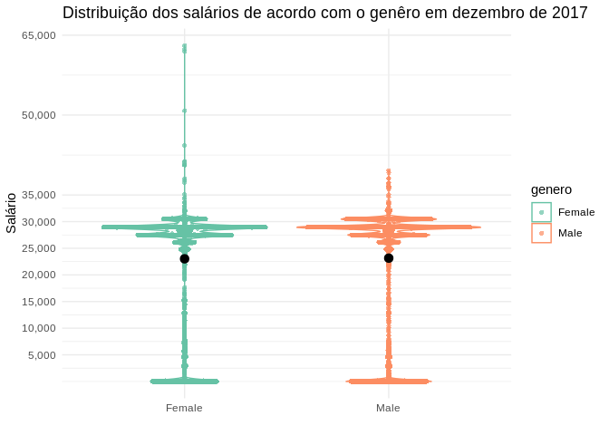

Média salárial (mulher): **23.020,62** Média salárial (homem): **23.147,46**

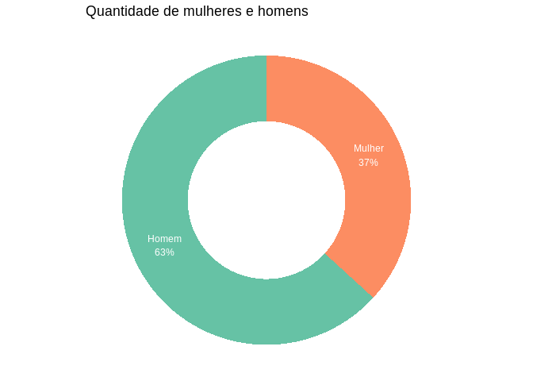

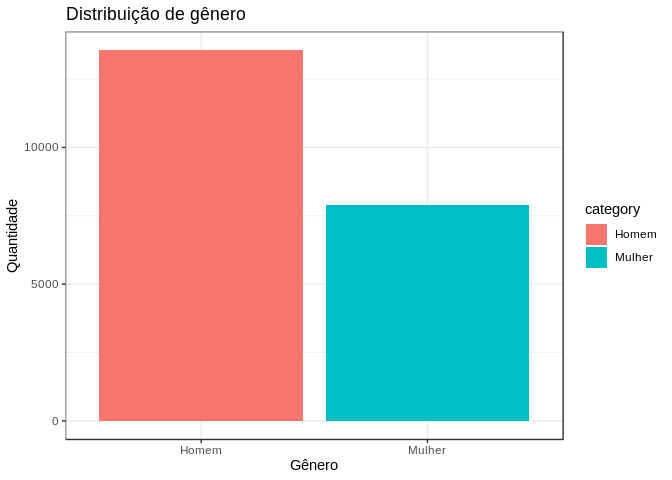

[figure not shown]

```r
data %>%
  ggplot(aes(x=category,y=count, fill=category)) +
  geom_bar(stat="identity") +
  labs(x="Gênero", y = "Quantidade", title = "Distribuição de gênero")
```

[figure not shown]

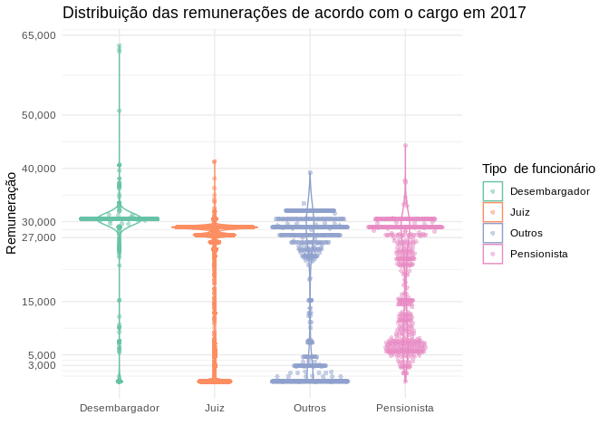

[figure not shown]

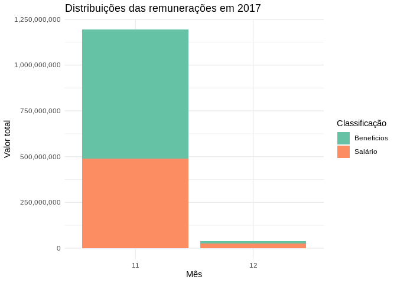

[figure not shown]

```r
data %>%
  ggplot(aes(x=category,y=count, fill=category)) +
  geom_bar(stat="identity") +
  labs(x="Cargo", y = "Quantidade", title = "Distribuição de cargos")
```

| type | mes | sum |
| --- | --- | --- |
| ajuda_de_custo | 11 | 1021993.90 |
| ajuda_de_custo | 12 | 57895.10 |
| auxilio_alimentacao | 11 | 13287394.28 |
| auxilio_alimentacao | 12 | 570494.53 |
| auxilio_moradia | 11 | 55978001.48 |
| auxilio_moradia | 12 | 2536894.53 |
| auxilio_natalidade | 11 | 8448.29 |
| auxilio_natalidade | 12 | 659.25 |
| auxilio_pre_escolar | 11 | 825828.91 |
| auxilio_pre_escolar | 12 | 96251.92 |
| auxilio_saude | 11 | 3194884.57 |
| auxilio_saude | 12 | 401269.78 |

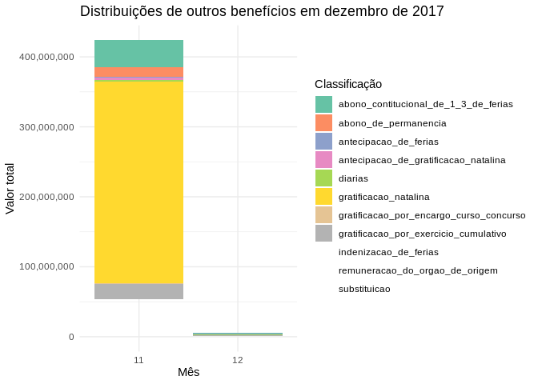

| type | mes | sum |
| --- | --- | --- |
| abono_contitucional_de_1_3_de_ferias | 11 | 38701803.9 |
| abono_contitucional_de_1_3_de_ferias | 12 | 606939.8 |
| abono_de_permanencia | 11 | 14079128.1 |
| abono_de_permanencia | 12 | 376705.4 |
| antecipacao_de_ferias | 11 | 990806.1 |
| antecipacao_de_ferias | 12 | 710738.5 |
| antecipacao_de_gratificacao_natalina | 11 | 3365846.9 |
| antecipacao_de_gratificacao_natalina | 12 | 627060.8 |
| diarias | 11 | 2112563.1 |
| diarias | 12 | 201950.3 |
| gratificacao_natalina | 11 | 288043915.6 |
| gratificacao_natalina | 12 | 180451.0 |
| gratificacao_por_encargo_curso_concurso | 11 | 1320547.1 |
| gratificacao_por_encargo_curso_concurso | 12 | 151485.8 |
| gratificacao_por_exercicio_cumulativo | 11 | 21886621.5 |
| gratificacao_por_exercicio_cumulativo | 12 | 1942036.6 |
| indenizacao_de_ferias | 11 | 46270943.7 |
| indenizacao_de_ferias | 12 | 346786.6 |
| remuneracao_do_orgao_de_origem | 11 | 4844985.3 |
| remuneracao_do_orgao_de_origem | 12 | 0.0 |
| substituicao | 11 | 2288061.8 |
| substituicao | 12 | 146791.5 |

### 2018

[output not shown]

[output cut: 65 more lines]

```
##  Min.   :-11254.3          Length:186965               Min.   : 1.000
##  1st Qu.:     0.0          Class :character            1st Qu.: 4.000
##  Median :     0.0          Mode  :character            Median : 6.000
##  Mean   :  1550.1                                      Mean   : 6.698
##  3rd Qu.:   775.5                                      3rd Qu.: 9.000
##  Max.   :167413.5                                      Max.   :12.000
##  NA's   :5393
##       ano          genero
##  Min.   :2018   Length:186965
##  1st Qu.:2018   Class :character
##  Median :2018   Mode  :character
##  Mean   :2018
##  3rd Qu.:2018
##  Max.   :2018
##
```

[figure not shown]

[figure not shown]

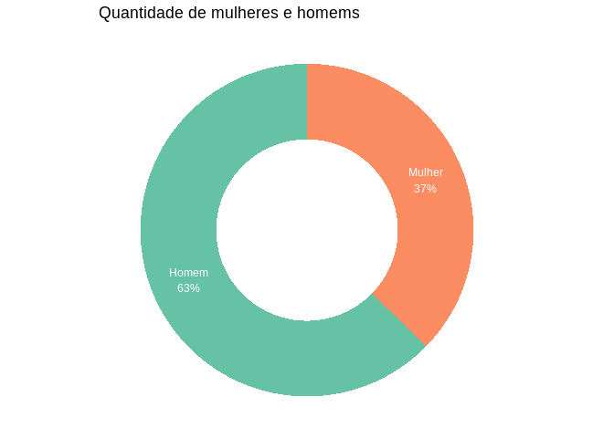

[figure not shown]

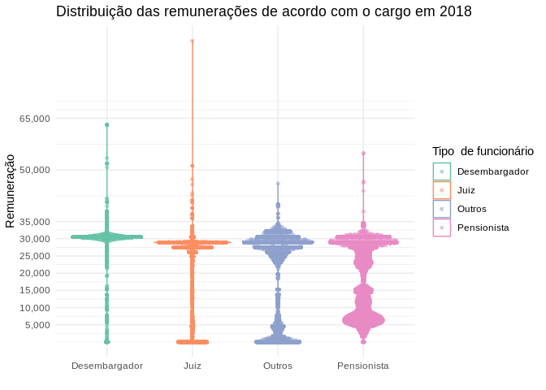

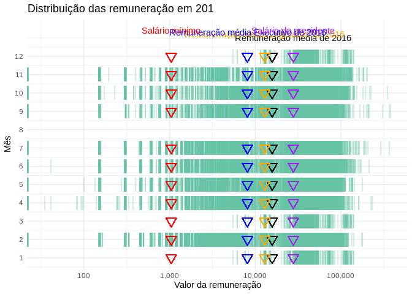

```r
dados_2018 %>% group_by(mes) %>%  summarise(sum  =  sum (subsidio))
```

| mes | sum |
| --- | --- |
| 1 | 24667955 |
| 2 | 551698624 |
| 3 | 24667955 |
| 4 | 556127047 |
| 5 | 548691480 |
| 6 | 538990129 |
| 7 | 554743220 |
| 9 | 554438707 |
| 10 | 558468781 |
| 11 | 510040248 |

[output cut: 1 more lines]

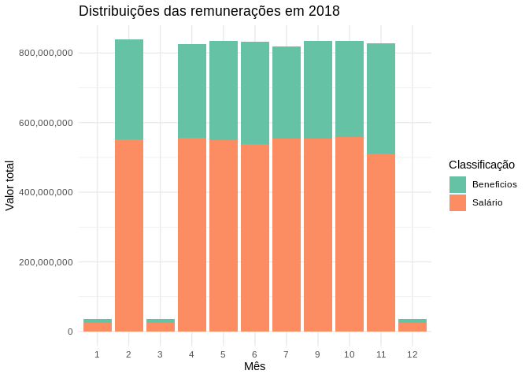

```
## [1] 4447202101
```

```
## [1] 2311938262
```

[figure not shown]

| type | mes | sum |
| --- | --- | --- |
| ajuda_de_custo | 1 | 57895.10 |
| ajuda_de_custo | 2 | 2171097.04 |
| ajuda_de_custo | 3 | 57895.10 |
| ajuda_de_custo | 4 | 1892231.38 |
| ajuda_de_custo | 5 | 1715279.98 |
| ajuda_de_custo | 6 | 2702315.00 |
| ajuda_de_custo | 7 | 3830928.44 |
| ajuda_de_custo | 9 | 2012170.45 |
| ajuda_de_custo | 10 | 1851242.17 |
| ajuda_de_custo | 11 | 1649921.35 |
| ajuda_de_custo | 12 | 57895.10 |
| auxilio_alimentacao | 1 | 570494.53 |
| auxilio_alimentacao | 2 | 15577977.19 |
| auxilio_alimentacao | 3 | 570494.53 |
| auxilio_alimentacao | 4 | 15990474.73 |
| auxilio_alimentacao | 5 | 16105776.68 |
| auxilio_alimentacao | 6 | 15363502.46 |
| auxilio_alimentacao | 7 | 16216617.57 |
| auxilio_alimentacao | 9 | 15830721.17 |
| auxilio_alimentacao | 10 | 16223764.22 |
| auxilio_alimentacao | 11 | 14876463.39 |
| auxilio_alimentacao | 12 | 570494.53 |
| auxilio_moradia | 1 | 2536894.53 |
| auxilio_moradia | 2 | 64310543.84 |
| auxilio_moradia | 3 | 2536894.53 |
| auxilio_moradia | 4 | 62414417.33 |
| auxilio_moradia | 5 | 62429633.74 |
| auxilio_moradia | 6 | 60030262.60 |
| auxilio_moradia | 7 | 60401196.18 |
| auxilio_moradia | 9 | 62073359.83 |
| auxilio_moradia | 10 | 62127268.87 |
| auxilio_moradia | 11 | 57789834.87 |
| auxilio_moradia | 12 | 2536894.53 |
| auxilio_natalidade | 1 | 659.25 |
| auxilio_natalidade | 2 | 6168.39 |
| auxilio_natalidade | 3 | 659.25 |
| auxilio_natalidade | 4 | 9811.46 |
| auxilio_natalidade | 5 | 6236.20 |
| auxilio_natalidade | 6 | 10126.60 |
| auxilio_natalidade | 7 | 4917.75 |
| auxilio_natalidade | 9 | 8896.50 |
| auxilio_natalidade | 10 | 7505.05 |
| auxilio_natalidade | 11 | 4817.97 |
| auxilio_natalidade | 12 | 659.25 |
| auxilio_pre_escolar | 1 | 96251.92 |
| auxilio_pre_escolar | 2 | 975739.15 |
| auxilio_pre_escolar | 3 | 96251.92 |
| auxilio_pre_escolar | 4 | 971374.85 |
| auxilio_pre_escolar | 5 | 901800.01 |
| auxilio_pre_escolar | 6 | 1031644.12 |
| auxilio_pre_escolar | 7 | 1038666.49 |
| auxilio_pre_escolar | 9 | 1007662.57 |
| auxilio_pre_escolar | 10 | 1023725.85 |
| auxilio_pre_escolar | 11 | 854264.91 |
| auxilio_pre_escolar | 12 | 96251.92 |
| auxilio_saude | 1 | 401269.78 |
| auxilio_saude | 2 | 4599824.11 |
| auxilio_saude | 3 | 401269.78 |
| auxilio_saude | 4 | 5005457.64 |
| auxilio_saude | 5 | 6079342.86 |
| auxilio_saude | 6 | 5107173.63 |
| auxilio_saude | 7 | 5079437.44 |
| auxilio_saude | 9 | 5615206.48 |
| auxilio_saude | 10 | 5617347.92 |
| auxilio_saude | 11 | 5378686.59 |
| auxilio_saude | 12 | 401269.78 |

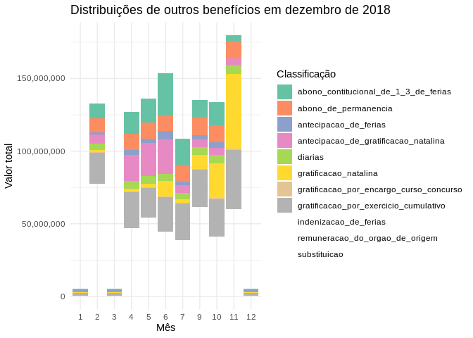

| type | mes | sum |
| --- | --- | --- |
| abono_contitucional_de_1_3_de_ferias | 1 | 606939.81 |
| abono_contitucional_de_1_3_de_ferias | 2 | 10173697.34 |
| abono_contitucional_de_1_3_de_ferias | 3 | 606939.81 |
| abono_contitucional_de_1_3_de_ferias | 4 | 15170737.64 |
| abono_contitucional_de_1_3_de_ferias | 5 | 16373518.16 |
| abono_contitucional_de_1_3_de_ferias | 6 | 28781232.97 |
| abono_contitucional_de_1_3_de_ferias | 7 | 18161751.74 |
| abono_contitucional_de_1_3_de_ferias | 9 | 12167738.38 |
| abono_contitucional_de_1_3_de_ferias | 10 | 16154669.10 |
| abono_contitucional_de_1_3_de_ferias | 11 | 4281397.51 |
| abono_contitucional_de_1_3_de_ferias | 12 | 606939.81 |
| abono_de_permanencia | 1 | 376705.41 |
| abono_de_permanencia | 2 | 9945743.57 |
| abono_de_permanencia | 3 | 376705.41 |
| abono_de_permanencia | 4 | 11193039.95 |
| abono_de_permanencia | 5 | 11322097.63 |
| abono_de_permanencia | 6 | 10943794.24 |
| abono_de_permanencia | 7 | 11418114.83 |
| abono_de_permanencia | 9 | 11971562.14 |
| abono_de_permanencia | 10 | 11624405.12 |
| abono_de_permanencia | 11 | 11712258.28 |
| abono_de_permanencia | 12 | 376705.41 |
| antecipacao_de_ferias | 1 | 710738.51 |
| antecipacao_de_ferias | 2 | 1228075.99 |
| antecipacao_de_ferias | 3 | 710738.51 |
| antecipacao_de_ferias | 4 | 3146105.65 |
| antecipacao_de_ferias | 5 | 2834818.23 |
| antecipacao_de_ferias | 6 | 5789885.15 |
| antecipacao_de_ferias | 7 | 2758370.22 |
| antecipacao_de_ferias | 9 | 2748035.42 |

[output cut: 91 more lines]

[figure not shown]

[figure not shown]

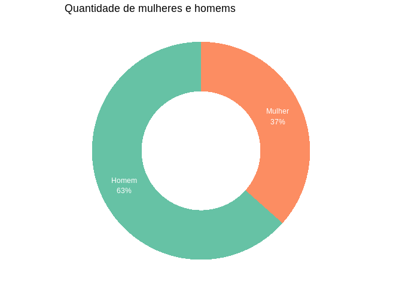

[figure not shown]

[figure not shown]

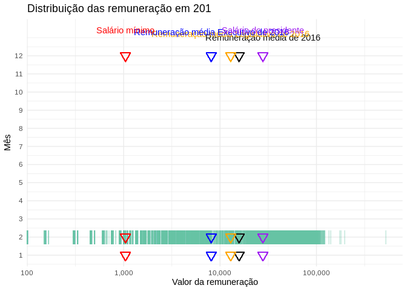

[figure not shown]

[figure not shown]

| type | mes | sum |
| --- | --- | --- |
| ajuda_de_custo | 1 | 57895.10 |
| ajuda_de_custo | 2 | 2317638.49 |
| ajuda_de_custo | 12 | 3832060.71 |
| auxilio_alimentacao | 1 | 1534578.85 |
| auxilio_alimentacao | 2 | 18350620.73 |
| auxilio_alimentacao | 12 | 18967369.26 |
| auxilio_moradia | 1 | 7230988.49 |
| auxilio_moradia | 2 | 77709385.98 |
| auxilio_moradia | 12 | 73351500.73 |
| auxilio_natalidade | 1 | 659.25 |
| auxilio_natalidade | 2 | 7486.89 |
| auxilio_natalidade | 12 | 6236.25 |
| auxilio_pre_escolar | 1 | 107765.84 |
| auxilio_pre_escolar | 2 | 1160404.21 |
| auxilio_pre_escolar | 12 | 1241157.90 |
| auxilio_saude | 1 | 4810980.96 |
| auxilio_saude | 2 | 9249994.56 |
| auxilio_saude | 12 | 9642970.73 |

[figure not shown]

| type | mes | sum |
| --- | --- | --- |
| abono_contitucional_de_1_3_de_ferias | 1 | 616106.5 |
| abono_contitucional_de_1_3_de_ferias | 2 | 12314975.4 |
| abono_contitucional_de_1_3_de_ferias | 12 | 21286427.6 |
| abono_de_permanencia | 1 | 1180701.3 |
| abono_de_permanencia | 2 | 12277734.3 |
| abono_de_permanencia | 12 | 13762554.9 |
| antecipacao_de_ferias | 1 | 710738.5 |
| antecipacao_de_ferias | 2 | -316927.1 |
| antecipacao_de_ferias | 12 | 601805.4 |
| antecipacao_de_gratificacao_natalina | 1 | 627060.8 |
| antecipacao_de_gratificacao_natalina | 2 | 6386972.7 |
| antecipacao_de_gratificacao_natalina | 12 | 27283886.9 |
| diarias | 1 | 272274.9 |
| diarias | 2 | 4694786.9 |
| diarias | 12 | 4619264.9 |
| gratificacao_natalina | 1 | 181858.2 |
| gratificacao_natalina | 2 | 1854819.8 |
| gratificacao_natalina | 12 | 2297855.0 |
| gratificacao_por_encargo_curso_concurso | 1 | 151485.8 |
| gratificacao_por_encargo_curso_concurso | 2 | 411678.7 |
| gratificacao_por_encargo_curso_concurso | 12 | 821685.1 |
| gratificacao_por_exercicio_cumulativo | 1 | 1957421.7 |
| gratificacao_por_exercicio_cumulativo | 2 | 26828282.7 |
| gratificacao_por_exercicio_cumulativo | 12 | 32506403.1 |
| indenizacao_de_ferias | 1 | 449626.6 |
| indenizacao_de_ferias | 2 | 63789782.6 |
| indenizacao_de_ferias | 12 | 21792312.7 |
| remuneracao_do_orgao_de_origem | 1 | 0.0 |
| remuneracao_do_orgao_de_origem | 2 | 11896168.4 |
| remuneracao_do_orgao_de_origem | 12 | 15182502.6 |
| substituicao | 1 | 191175.2 |
| substituicao | 2 | 6493697.6 |
| substituicao | 12 | 5871590.4 |

### Dados Brasil.io

```r
dados_brasil_io = read_csv(here("dados/contracheque.csv"))
```

### Planos

- Grafico de barras stacked para ver o quanto de gasta com indenização salario e outros
- Mostrar média salaria por mês do sistema de justiça x executivo x legislativo
- Ditribuição dos auxilios, quais os mais utilizados? quais os que são mais gatos?
- distribuição das remunerção e descrever alguns outiliers
- Média salarial comparada com algumas outras profissões
- Questões de genêro